# Project Proposal

Maris Grundy 10/13/2021

## Introduction

### Hypothesis

I hypothesize that areas of lower mean household income will be geographically farther from intact wetlands in Erie County.

## Inspiring Examples

Here are some examples of graphics I would like to create:

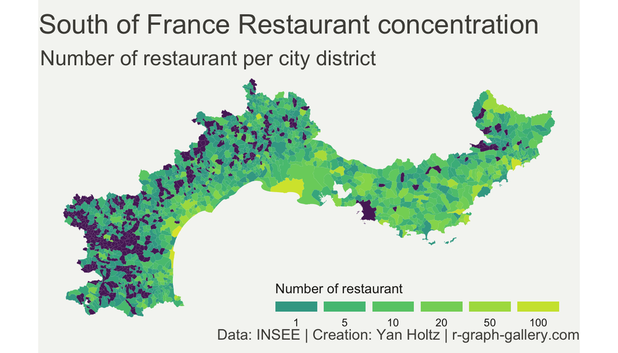

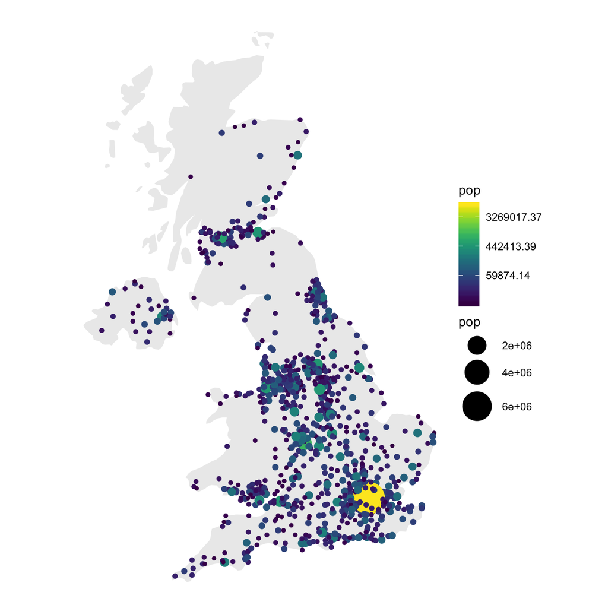

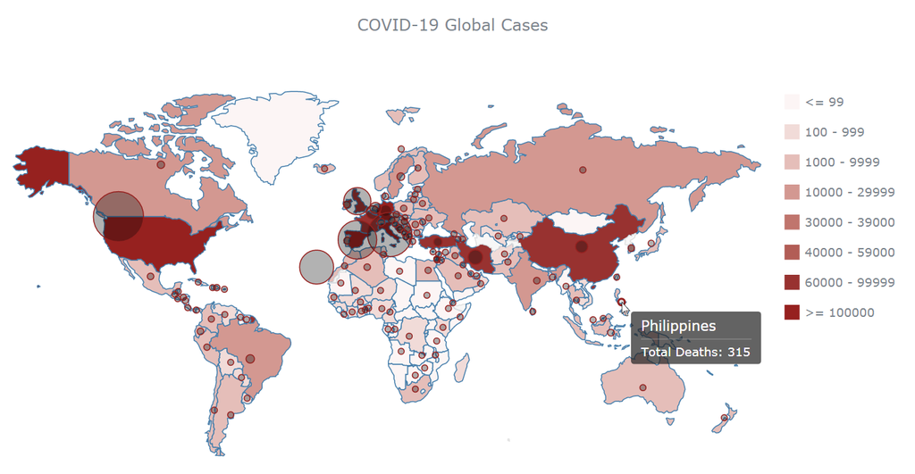

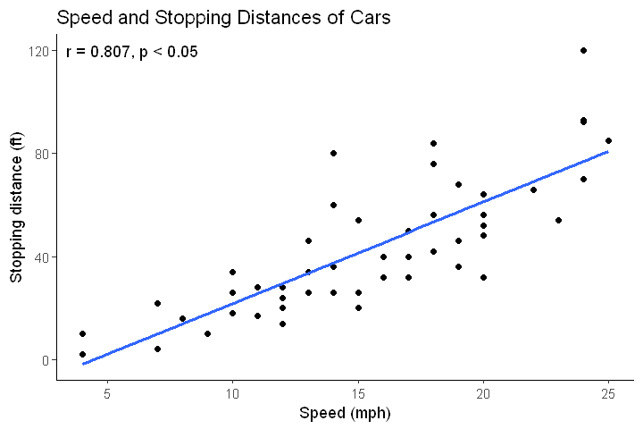

## Proposed Data Sources

My proposed data sources are: [National Wetlands Inventory](https://www.fws.gov/wetlands/data/Mapper.html) and [Census Data](https://data.census.gov/cedsci/)

## Proposed Methods

```r
library(spData)
library(sf)
library(tidyverse)
library(units)
library(ggplot2)
library(viridis)
library(broom)
library(dplyr)
```

**All code shown below is to demonstrate something similar to what the final code will be-not a representation of the actual code!**

**Also, I need to figure out how the data will need to be prepped, but you’ll get the idea…**

### 1. Choropleth map with a bubble map

*choropleth* I plan to create a choropleth map that shows how many wetlands are in each census tract so I will need: - A geospatial object providing region boundaries= from census data - A numeric variable to color each geographical unit= wetland mapper (fill=value)

*bubble* On top of the choropleth map from above, I plan to overlay a static bubble map showing mean household income

*To create the choropleth/bubble*

```r
#I know there is some spatial join that will need to occur first!

#then I will fortify geospatial data
library(broom)
  tidy_data<-(tidy(geospatial, region="wetland"))

#then I will plot numeric variable (number of wetlands) onto geospatial object (choropleth map)
  #I plan to play with themes more when I make this
ggplot() +
  geom_polygon(data = tidy_data, aes( x = long, y = lat, group=group, fill=value)) +
  scale_fill_gradient(high = "#e34a33", low = "#fee8c8", guide = "colorbar")+
  theme_void() +
  coord_map() +
    guides(fill=guide_colorbar(title="HP Index"))+
    theme(legend.justification=c(0,0), legend.position=c(0,0))

#then to add the bubble
 arrange(mean_income) %>%
 mutate( name=factor(name, unique(name))) %>%
 ggplot() +
    geom_polygon(data = mean_income, aes(x=long, y = lat, group = group), fill="grey", alpha=0.3) +
    geom_point( aes(x=long, y=lat, size=pop, color=pop), alpha=0.9) +
    scale_size_continuous(range=c(1,12)) +
    scale_color_viridis(trans="log") +
    theme_void() + ylim(50,59) + coord_map()
```

Inspiration for the above code

### 2. Scatterplot

I will also create a scatterplot that shows possible correlation between 2 relevant numerical values (x= mean household income in tract, y=number of wetlands in tract)

*To create the scatterplot*

```r
ggplot(data_source, aes(x=mean_income, y=num_wetlands))+
geom_point()+
  geom_smooth
```

## Expected Results

1. A graphic (bubble and choropleth map) that displays wetland extent and mean income for census tracts in Erie County.
2. A graphic (scatterplot) that shows possible correlation between mean household income in 2019 and number of wetlands present within each census tract.